# Master IA: Métodos supervisados

Manuel Jesús Jimnémez Navarro

17 de noviembre de 2019

# Master IA: Métodos supervisados

### Índice

1. Contexto del problema
2. Descripción de los datos
3. Evaluación
4. Visualización y preprocesado
5. Modelado
6. Resultados
7. Conclusiones

### Contexto del problema

Diariamente un gran número de animales son abandonados y recogidos por refugios de animales. Muchos de estos animales poseen diversos problemas para volver a reincorporarse a una nueva familia debido a varios factores. En el presente estudio se pretende clasificar cual será el destino de los animales del refugio dependiendo de sus características y así dar una mayor ayuda a aquellos animales que tengan menos probabilidades de poderser adoptados.

### Descripción de los datos

Los datos recogidos provienen del centro de animales de Austin [1] recogidos desde el 1 de Octubre de 2013 hasta Marzo de 2016. La variable objetivo representa el estado en el que el animal adoptado abandona el centro. Los posibles estados en los que los animales pueden abandonar el centro son 5: Adopción, muerte, eutanasia, vuelta al dueño y transferido. Como variables descriptoras se tiene las siguientes:

- AnimalId: Identificador único asignado al animal recogido.
- Name: Nombre del animal.
- Datetime: Fecha en la que se recogió.
- AnimalType: Tipo de animal del que se trata (perro, gato..).
- SexUponOutcome: Sexo del animal y si fue castrado/esterilizado/dejado intacto.
- AgeUponOutcome: Edad del animal aproximada.
- Breed: Raza del animal.
- Color: Color del pelaje del animal.

### Visualización Preprocesado

En esta sección se realizarán algunas visualizaciones sencillas de los datos así como distintas métricas y visualizaciones con el objetivo de realizar el preprocesado necesario.

En primer lugar, se observarán una muestra de los datos y así poder familiarizarse con los datos.

```r
head(train)
```

```
##   AnimalID    Name            DateTime     OutcomeType OutcomeSubtype
## 1  A671945 Hambone 2014-02-12 18:22:00 Return_to_owner           <NA>
## 2  A656520   Emily 2013-10-13 12:44:00      Euthanasia      Suffering
## 3  A686464  Pearce 2015-01-31 12:28:00        Adoption         Foster
## 4  A683430    <NA> 2014-07-11 19:09:00        Transfer        Partner
## 5  A667013    <NA> 2013-11-15 12:52:00        Transfer        Partner
## 6  A677334    Elsa 2014-04-25 13:04:00        Transfer        Partner
##   AnimalType SexuponOutcome AgeuponOutcome                             Breed
## 1        Dog  Neutered Male         1 year             Shetland Sheepdog Mix
## 2        Cat  Spayed Female         1 year            Domestic Shorthair Mix
## 3        Dog  Neutered Male        2 years                      Pit Bull Mix
## 4        Cat    Intact Male        3 weeks            Domestic Shorthair Mix
## 5        Dog  Neutered Male        2 years       Lhasa Apso/Miniature Poodle
## 6        Dog  Intact Female        1 month Cairn Terrier/Chihuahua Shorthair
##         Color
## 1 Brown/White
## 2 Cream Tabby
## 3  Blue/White
## 4  Blue Cream
## 5         Tan
## 6   Black/Tan
```

En segundo lugar se realizará un análisis de distintos estadísticos de los datos.

```r
str(train)
```

```
## 'data.frame':    26729 obs. of  10 variables:
##  $ AnimalID      : Factor w/ 26729 levels "A006100","A047759",..: 5420 1604 11614 10239 3502 7396 17152 18183 5373 7574 ...
##  $ Name          : Factor w/ 6374 levels "'Stache"," Joanie",..: 2352 1848 4441 NA NA 1836 2762 NA 3457 NA ...
##  $ DateTime      : Factor w/ 22918 levels "2013-10-01 09:31:00",..: 3362 351 12682 7191 1234 5022 13873 14619 3214 5210 ...
##  $ OutcomeType   : Factor w/ 5 levels "Adoption","Died",..: 4 3 1 5 5 5 5 5 1 1 ...
##  $ OutcomeSubtype: Factor w/ 16 levels "Aggressive","At Vet",..: NA 16 7 13 13 13 13 13 NA 12 ...
##  $ AnimalType    : Factor w/ 2 levels "Cat","Dog": 2 1 2 1 2 2 1 1 2 2 ...
##  $ SexuponOutcome: Factor w/ 5 levels "Intact Female",..: 3 4 3 2 3 1 2 5 4 4 ...
##  $ AgeuponOutcome: Factor w/ 44 levels "0 years","1 day",..: 6 6 22 26 22 3 26 26 33 6 ...
##  $ Breed         : Factor w/ 1380 levels "Abyssinian Mix",..: 1222 641 1067 641 915 370 641 641 46 365 ...
##  $ Color         : Factor w/ 366 levels "Agouti","Agouti/Brown Tabby",..: 131 168 87 43 275 37 64 105 251 319 ...
```

A continuación, se estudiarán distintas métricas sobre los datos:

```r
summary(train)
```

```
##       Name                      DateTime              OutcomeType
##  Max    :  136   2015-08-11 00:00:00:   19   Adoption       :10769
##  Bella  :  135   2015-11-17 00:00:00:   17   Died           :  197
##  Charlie:  107   2015-07-02 00:00:00:   13   Euthanasia     : 1555
##  Daisy  :  106   2015-04-02 00:00:00:   11   Return_to_owner: 4786
##  Lucy   :   94   2014-08-31 09:00:00:   10   Transfer       : 9422
##  (Other):18460   2014-08-26 09:00:00:    9
##  NA's   : 7691   (Other)            :26650
##  AnimalType        SexuponOutcome  AgeuponOutcome
##  Cat:11134   Intact Female:3511   1 year  : 3969
##  Dog:15595   Intact Male  :3525   2 years : 3742
##              Neutered Male:9779   2 months: 3397
##              Spayed Female:8820   3 years : 1823
##              Unknown      :1093   1 month : 1281
##              NA's         :   1   (Other) :12499
##                                   NA's    :   18
##                       Breed                     Color
##  Domestic Shorthair Mix  : 8810   Black/White      : 2824
##  Pit Bull Mix            : 1906   Black            : 2292
##  Chihuahua Shorthair Mix : 1766   Brown Tabby      : 1635
##  Labrador Retriever Mix  : 1363   Brown Tabby/White:  940
##  Domestic Medium Hair Mix:  839   White            :  931
##  German Shepherd Mix     :  575   Brown/White      :  884
##  (Other)                 :11470   (Other)          :17223
```

En esta tabla se muestra principalmente la distribución de datos sobre una muestra de los ejemplos. De aquí se destacará lo más interesante. Por un lado, se observa en la distribución de la clase que estamos ante un problema desbalanceado. Se puede ver que la adopción es el tipo de destino más común seguido de la transferencia. La devolución al dueño es un poco menos común, y la eutanasia y la muerte son los destinos menos comunes. Al tratarse de un problema desbalanceado sería necesario tener en cuenta un modelo robusto a este fenómeno. Por otro lado, la distribución de animales no es igual, aunque si es parecida. En el caso del sexo, se observa que existe un valor perdido, esto puede ser debido a algún error o cualquier otro tipo de problema. En cualquier caso, este valor será ignorado. En el caso de la edad se observa que existen 18 ejemplos donde la edad es desconocida, en este caso se puede, o bien eliminar dichos ejemplos o intentar “recuperar” estos valores perdidos. Al poseer bastantes ejemplos no se ve la necesidad de invertir esfuerzo en recuperarlos, por lo tanto, se eliminarán.

En este momento es necesario se realizar ciertas transformaciones sobre los datos de entrenamiento para proseguir con el análisis. En primer lugar, se eliminarán los registros correspondientes a los datos perdidos visualizados anteriormente excepto para los del nombre (posteriormente veremos porqué).

```r
train = train[!is.na(train$SexuponOutcome),]
train = train[!is.na(train$AgeuponOutcome),]

sapply(train, function(x) sum(is.na(x)))
```

```
##           Name       DateTime    OutcomeType     AnimalType SexuponOutcome
##           7673              0              0              0              0
## AgeuponOutcome          Breed          Color
##              0              0              0
```

Una vez realizado esto, será necesario procesar los atributos. El primer atributo que se tratará será el nombre, este atributo en sí no aporta gran información a la hora de decidir su destino a priori. Sin embargo, cabe esperar que un animal encontrado que posea un nombre es más probable que sea perdido a abandonado y por lo tanto es más probable que se devuelva al dueño. Por lo tanto, en el caso del nombre se convertirá en un valor booleano que indicará la existencia o no de nombre.

```r
train$Name = is.na(train$Name)
str(train)
```

```
## 'data.frame':    26710 obs. of  8 variables:
##  $ Name          : logi  FALSE FALSE FALSE TRUE TRUE FALSE ...
##  $ DateTime      : Factor w/ 22918 levels "2013-10-01 09:31:00",..: 3362 351 12682 7191 1234 5022 13873 14619 3214 5210 ...
##  $ OutcomeType   : Factor w/ 5 levels "Adoption","Died",..: 4 3 1 5 5 5 5 5 1 1 ...
##  $ AnimalType    : Factor w/ 2 levels "Cat","Dog": 2 1 2 1 2 2 1 1 2 2 ...
##  $ SexuponOutcome: Factor w/ 5 levels "Intact Female",..: 3 4 3 2 3 1 2 5 4 4 ...
##  $ AgeuponOutcome: Factor w/ 44 levels "0 years","1 day",..: 6 6 22 26 22 3 26 26 33 6 ...
##  $ Breed         : Factor w/ 1380 levels "Abyssinian Mix",..: 1222 641 1067 641 915 370 641 641 46 365 ...
##  $ Color         : Factor w/ 366 levels "Agouti","Agouti/Brown Tabby",..: 131 168 87 43 275 37 64 105 251 319 ...
```

Por otro lado, la fecha no es demasiado “usable” de esta forma, es necesario pasarla a un formato en el que se pueda usar de una forma mas cómoda para el modelo. Por lo tanto, se separará la fecha en año, mes, día y hora (se obviarán los minutos y segundos al considerarse irrelevantes). Estos valores pueden aportar información útil, ya que es bien sabido que hay épocas del año donde más animales se abandonan o se pierden (fin de temporada de caza, vacaciones…). También es más probable perder a un animal durante la noche que durante el día. Por ello, se separarán estos datos de esta forma.

```r
train$Year = as.numeric(format(as.Date(train$DateTime), '%Y'))
train$Month = as.numeric(format(as.Date(train$DateTime), '%m'))
train$Day = as.numeric(format(as.Date(train$DateTime), '%d'))
train$Hour = as.numeric(format(as.POSIXct(train$DateTime,format="%Y-%m-%d %H:%M:%S"), '%H'))
train$DateTime = NULL

str(train)
```

```
## 'data.frame':    26710 obs. of  11 variables:
##  $ Name          : logi  FALSE FALSE FALSE TRUE TRUE FALSE ...
##  $ OutcomeType   : Factor w/ 5 levels "Adoption","Died",..: 4 3 1 5 5 5 5 5 1 1 ...
##  $ AnimalType    : Factor w/ 2 levels "Cat","Dog": 2 1 2 1 2 2 1 1 2 2 ...
##  $ SexuponOutcome: Factor w/ 5 levels "Intact Female",..: 3 4 3 2 3 1 2 5 4 4 ...
##  $ AgeuponOutcome: Factor w/ 44 levels "0 years","1 day",..: 6 6 22 26 22 3 26 26 33 6 ...
##  $ Breed         : Factor w/ 1380 levels "Abyssinian Mix",..: 1222 641 1067 641 915 370 641 641 46 365 ...
##  $ Color         : Factor w/ 366 levels "Agouti","Agouti/Brown Tabby",..: 131 168 87 43 275 37 64 105 251 319 ...
##  $ Year          : num  2014 2013 2015 2014 2013 ...
##  $ Month         : num  2 10 1 7 11 4 3 4 2 5 ...
##  $ Day           : num  12 13 31 11 15 25 28 30 4 3 ...
##  $ Hour          : num  18 12 12 19 12 13 13 17 17 7 ...
```

En el caso del sexo, si se observa que el atributo posee dos tipos de información: el propio sexo y la existencia de esterilización/castración. Por lo tanto se separará esta información para facilitar el modelado. En primer luga, se observarán los distintos valores:

```r
unique(train$SexuponOutcome)
```

```
## [1] Neutered Male Spayed Female Intact Male   Intact Female Unknown
## Levels: Intact Female Intact Male Neutered Male Spayed Female Unknown
```

Se observa que existen ciertos valores desconocidos, este valor podría considerarse como un valor perdido, sin embargo, es posible puede aportar información útil. Por lo tanto, se obtendrá un tercer atributo indicando si la esterilización/castración es desconocida o no. Se observa que existen animales donde el sexo no se considera, dado de que se trata de una gran cantidad de muestras, se sustituirán dichos valores con el sexo mayoritario, en este caso el masculino.

```r
train$isSNUnknown = train$SexuponOutcome=="Unknown"
train$isSN <- str_split_fixed(as.character(train$SexuponOutcome), " ", 2)[,1]
train$sex <- str_split_fixed(as.character(train$SexuponOutcome), " ", 2)[,2]
train$sex[as.character(train$sex)==""] = "Male"
train$sex[is.na(train$sex)] = "Male"
train$isSN = !(train$isSN %like% "Intact" | train$isSN %like% "Unknown")
train$SexuponOutcome = NULL


summary(train)
```

```
##     Name                  OutcomeType    AnimalType   AgeuponOutcome
##  Mode :logical   Adoption       :10769   Cat:11117   1 year  : 3969
##  FALSE:19037     Died           :  197   Dog:15593   2 years : 3742
##  TRUE :7673      Euthanasia     : 1553               2 months: 3397
##                  Return_to_owner: 4785               3 years : 1823
##                  Transfer       : 9406               1 month : 1281
##                                                      3 months: 1277
##                                                      (Other) :11221
##                       Breed                     Color            Year
##  Domestic Shorthair Mix  : 8794   Black/White      : 2824   Min.   :2013
##  Pit Bull Mix            : 1906   Black            : 2288   1st Qu.:2014
##  Chihuahua Shorthair Mix : 1766   Brown Tabby      : 1631   Median :2014
##  Labrador Retriever Mix  : 1363   Brown Tabby/White:  939   Mean   :2014
##  Domestic Medium Hair Mix:  839   White            :  930   3rd Qu.:2015
##  German Shepherd Mix     :  575   Brown/White      :  884   Max.   :2016
##  (Other)                 :11467   (Other)          :17214
##      Month             Day            Hour       isSNUnknown
##  Min.   : 1.000   Min.   : 1.0   Min.   : 0.00   Mode :logical
##  1st Qu.: 4.000   1st Qu.: 8.0   1st Qu.:12.00   FALSE:25621
##  Median : 7.000   Median :16.0   Median :15.00   TRUE :1089
##  Mean   : 6.929   Mean   :15.7   Mean   :14.45
##  3rd Qu.:10.000   3rd Qu.:23.0   3rd Qu.:17.00
##  Max.   :12.000   Max.   :31.0   Max.   :23.00
##
##     isSN             sex
##  Mode :logical   Length:26710
##  FALSE:8112      Class :character
##  TRUE :18598     Mode  :character
##
##
##
##
```

En el caso de la edad, se tiene la edad dada en medida categórica en función de días, meses o años. Podría considerarse convertir estos valores a numéricos mediante una categorización numérica. Sin embargo, dado que la magnitud del valor es influyente, la diferencia entre los valores deberían ser continuos. Por ejemplo, si se codifica como 3 la categoría 1 Months, y 4 como el valor “5 Months” se observa que la diferencia en cuanto a valor categórico es 1 pero conceptualmente los valores no tienen esa diferencia. Es decir, se necesita mostrar de forma numérica la diferencia en cuanto a la magnitud de los distintos valores. Por ello, es necesario convertir todos los valores a días al ser la unidad mínima mostrada.

```r
ageValue = as.numeric(sapply(as.character(train$AgeuponOutcome),
                      function(x) strsplit(x, split = ' ')[[1]][1]))
ageUnit = sapply(as.character(train$AgeuponOutcome),
                      function(x) strsplit(x, split = ' ')[[1]][2])
ageUnit = gsub('s', '', ageUnit)

unique(ageUnit)
```

```
## [1] "year"  "week"  "month" "day"
```

```r
daysForUnit = ifelse(ageUnit == 'day', 1,
              ifelse(ageUnit == 'week', 7,
              ifelse(ageUnit == 'month', 30,
              ifelse(ageUnit == 'year', 365, NA))))

train$AgeInDays = ageValue * daysForUnit
train$AgeuponOutcome = NULL

str(train)
```

```
## 'data.frame':    26710 obs. of  13 variables:
##  $ Name       : logi  FALSE FALSE FALSE TRUE TRUE FALSE ...
##  $ OutcomeType: Factor w/ 5 levels "Adoption","Died",..: 4 3 1 5 5 5 5 5 1 1 ...
##  $ AnimalType : Factor w/ 2 levels "Cat","Dog": 2 1 2 1 2 2 1 1 2 2 ...
##  $ Breed      : Factor w/ 1380 levels "Abyssinian Mix",..: 1222 641 1067 641 915 370 641 641 46 365 ...
##  $ Color      : Factor w/ 366 levels "Agouti","Agouti/Brown Tabby",..: 131 168 87 43 275 37 64 105 251 319 ...
##  $ Year       : num  2014 2013 2015 2014 2013 ...
##  $ Month      : num  2 10 1 7 11 4 3 4 2 5 ...
##  $ Day        : num  12 13 31 11 15 25 28 30 4 3 ...
##  $ Hour       : num  18 12 12 19 12 13 13 17 17 7 ...
##  $ isSNUnknown: logi  FALSE FALSE FALSE FALSE FALSE FALSE ...
##  $ isSN       : logi  TRUE TRUE TRUE FALSE TRUE FALSE ...
##  $ sex        : chr  "Male" "Female" "Male" "Male" ...
##  $ AgeInDays  : num  365 365 730 21 730 30 21 21 150 365 ...
```

En cuanto a la raza, se puede transformar a numérico estos valores categóricos. Sin embargo, si se observan los datos, se ve como existe el término mezcla si se desconoce las posibles razas de la ascendencia o unos valores separados por una barra lateral. Un animal con una raza pura es más probable que sea un animal abandonado, al igual que una raza donde la mezcla se pueda identificar claramente. En el caso de la mezcla puede asociarse a un animal con más probabilidad a ser abandonado o ser callejero. Por lo tanto, de este atributo se obtendrán tres, la raza primaria, la raza secundaria (que puede tener o no) y si se trata de un mestizo (mezcla de varios).

```r
unique(train$Breed)[1:30]
```

```
##  [1] Shetland Sheepdog Mix              Domestic Shorthair Mix
##  [3] Pit Bull Mix                       Lhasa Apso/Miniature Poodle
##  [5] Cairn Terrier/Chihuahua Shorthair  American Pit Bull Terrier Mix
##  [7] Cairn Terrier                      Miniature Schnauzer Mix
##  [9] Yorkshire Terrier Mix              Great Pyrenees Mix
## [11] Angora Mix                         Flat Coat Retriever Mix
## [13] Queensland Heeler Mix              Plott Hound/Boxer
## [15] German Shepherd Mix                American Staffordshire Terrier Mix
## [17] Chihuahua Shorthair Mix            Russian Blue Mix
## [19] Labrador Retriever Mix             Collie Smooth/German Shepherd
## [21] Domestic Longhair Mix              Beagle
## [23] Pit Bull/Labrador Retriever        Blue Lacy Mix
## [25] Black Mouth Cur Mix                Dachshund/Beagle
## [27] Dachshund Mix                      Maltese Mix
## [29] Pointer Mix                        English Foxhound
## 1380 Levels: Abyssinian Mix Affenpinscher Mix ... Yorkshire Terrier/Toy Poodle
```

```r
train$isMix = tolower(as.character(train$Breed)) %like% "mix"
breedWithoutMix = gsub('mix', '',  tolower(as.character(train$Breed)))
breedWithoutMix = gsub("^\\s+|\\s+$", "", breedWithoutMix)
train$firstBreed <- str_split_fixed(as.character(breedWithoutMix), "/", 2)[,1]
train$secondBreed <- str_split_fixed(as.character(breedWithoutMix), "/", 2)[,2]
train$secondBreed[as.character(train$secondBreed)==""] = NA
train$Breed = NULL

str(train)
```

```
## 'data.frame':    26710 obs. of  15 variables:
##  $ Name       : logi  FALSE FALSE FALSE TRUE TRUE FALSE ...
##  $ OutcomeType: Factor w/ 5 levels "Adoption","Died",..: 4 3 1 5 5 5 5 5 1 1 ...
##  $ AnimalType : Factor w/ 2 levels "Cat","Dog": 2 1 2 1 2 2 1 1 2 2 ...
##  $ Color      : Factor w/ 366 levels "Agouti","Agouti/Brown Tabby",..: 131 168 87 43 275 37 64 105 251 319 ...
##  $ Year       : num  2014 2013 2015 2014 2013 ...
##  $ Month      : num  2 10 1 7 11 4 3 4 2 5 ...
##  $ Day        : num  12 13 31 11 15 25 28 30 4 3 ...
##  $ Hour       : num  18 12 12 19 12 13 13 17 17 7 ...
##  $ isSNUnknown: logi  FALSE FALSE FALSE FALSE FALSE FALSE ...
##  $ isSN       : logi  TRUE TRUE TRUE FALSE TRUE FALSE ...
##  $ sex        : chr  "Male" "Female" "Male" "Male" ...
##  $ AgeInDays  : num  365 365 730 21 730 30 21 21 150 365 ...
##  $ isMix      : logi  TRUE TRUE TRUE TRUE FALSE FALSE ...
##  $ firstBreed : chr  "shetland sheepdog" "domestic shorthair" "pit bull" "domestic shorthair" ...
##  $ secondBreed: chr  NA NA NA NA ...
```

En el caso del color también pueden existir dos valores. Se procederá a separarlo en dos atributos.

```r
colorTrimmed = gsub("^\\s+|\\s+$", "", train$Color)
unique(train$Color)
```

```
##   [1] Brown/White                 Cream Tabby
##   [3] Blue/White                  Blue Cream
##   [5] Tan                         Black/Tan
##   [7] Blue Tabby                  Brown Tabby
##   [9] Red/White                   White
##  [11] Black                       Silver
##  [13] Brown                       Black/Red
##  [15] White/Cream                 Orange Tabby/White
##  [17] Black/White                 Brown Brindle/White
##  [19] Black/Brown                 Orange Tabby
##  [21] Chocolate/White             White/Tan
##  [23] Cream Tabby/White           Blue
##  [25] Calico                      Torbie
##  [27] Brown/Black                 Yellow
##  [29] Tricolor                    White/Black
```

[output cut: 169 more lines]

```r
train$firstColor <- str_split_fixed(as.character(colorTrimmed), "/", 2)[,1]
train$secondCOlor <- str_split_fixed(as.character(colorTrimmed), "/", 2)[,2]
train$Color = NULL

# train$sex
summary(train)
```

```
##     Name                  OutcomeType    AnimalType       Year
##  Mode :logical   Adoption       :10769   Cat:11117   Min.   :2013
##  FALSE:19037     Died           :  197   Dog:15593   1st Qu.:2014
##  TRUE :7673      Euthanasia     : 1553               Median :2014
##                  Return_to_owner: 4785               Mean   :2014
##                  Transfer       : 9406               3rd Qu.:2015
##                                                      Max.   :2016
##      Month             Day            Hour       isSNUnknown
##  Min.   : 1.000   Min.   : 1.0   Min.   : 0.00   Mode :logical
##  1st Qu.: 4.000   1st Qu.: 8.0   1st Qu.:12.00   FALSE:25621
##  Median : 7.000   Median :16.0   Median :15.00   TRUE :1089
##  Mean   : 6.929   Mean   :15.7   Mean   :14.45
##  3rd Qu.:10.000   3rd Qu.:23.0   3rd Qu.:17.00
##  Max.   :12.000   Max.   :31.0   Max.   :23.00
##     isSN             sex              AgeInDays        isMix
##  Mode :logical   Length:26710       Min.   :   0.0   Mode :logical
##  FALSE:8112      Class :character   1st Qu.:  60.0   FALSE:4430
##  TRUE :18598     Mode  :character   Median : 365.0   TRUE :22280
##                                     Mean   : 794.1
##                                     3rd Qu.:1095.0
##                                     Max.   :7300.0
##   firstBreed        secondBreed         firstColor        secondCOlor
##  Length:26710       Length:26710       Length:26710       Length:26710
##  Class :character   Class :character   Class :character   Class :character
##  Mode  :character   Mode  :character   Mode  :character   Mode  :character
##
##
##
```

```r
#write.csv(train, "train_processed2.csv")
```

Tras esto, se obtendrán algunos gráficos con el objetivo de obtener una mayor comprensión sobre los datos, en específico, se estudiará el comportamiento de los datos respecto la clase para intentar observar posibles correlaciones.

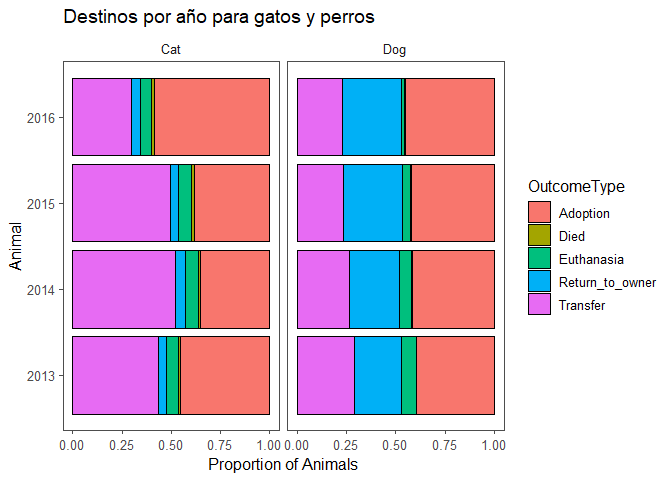

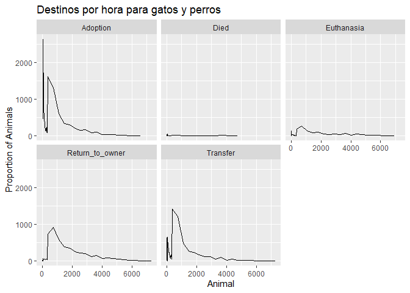

En esta gráfica se intenta analizar el comportamiento de los destinos respecto la edad del animal. Se observa que la adopción posee un valor extremadamente alto en casos donde la edad sea muy temprana (pocos días o meses) y va decreciendo conforme la edad avanza. Por otro lado, la devuelta al dueño es común en casos donde el animal tiene una edad ya un poco madura. Esto tiene sentido, ya que antes es muy probable que no pueda salir siquiera, además, decrece conforme el animal es mayor, al igual que pasa con la adopción. La transferencia se comporta de manera similar a la adopción, pero con un valor menor en edades muy tempranas. La eutanasia y muerte muestran oscilaciones mayores en edades muy tempranas o en edades donde se tiene un animal acabado de madurar.

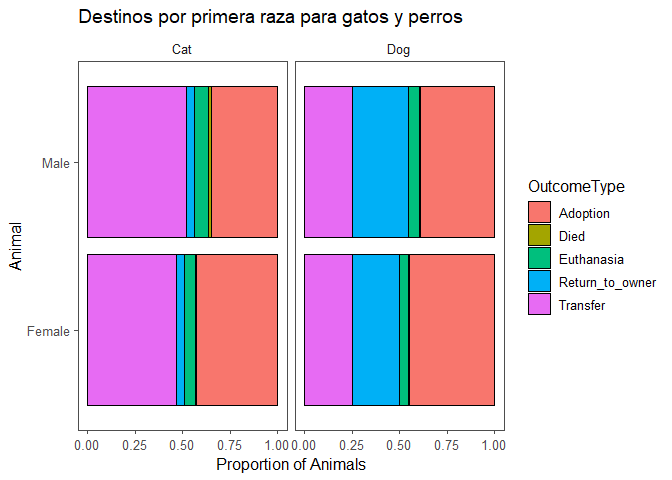

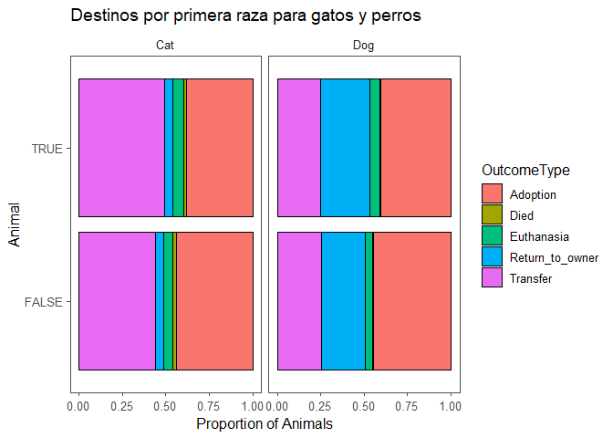

En esta gráfica se compara la proporción por cada tipo de animal de los distintos destinos. Se observa como en el caso de que se trate de una mezcla los valores de adopción decrecen aumentando el de eutanasia y devuelta al dueño en el caso de los perros y aumento en la transferencia solo en el caso de los gatos.

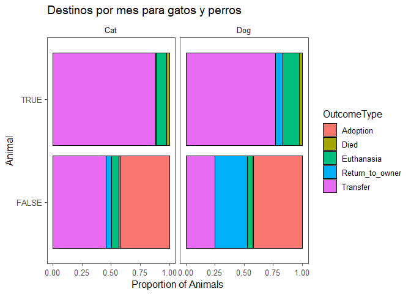

En el caso del desconocimiento de la castración/esterilización se observa que influye mucho. En el caso de que sea desconocido, la adopción se hace prácticamente imposible y las opciones que son más posibles son la transferencia o la eutanasia. Destacar que en el caso de los perros es mucho más probable el retorno al dueño que en el caso de los gatos.

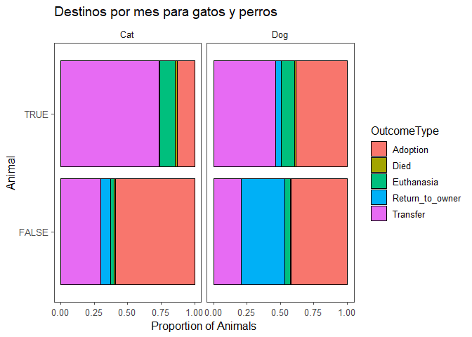

El nombre también tiene una gran influencia en los resultados, en el caso de que no lo posea, la devuelta al dueño decrece en gran medida incrementándose la probabilidad de eutanasia o transferencia.

Una vez analizado, ya solo quedan los últimos retoques con el objetivo de dejar los datos listos para la fase de modelado. Para ello, se realizará una transformación a numérico de los distintos atributos que queden por transformar y posteriormente se realizará un escalado y centrado de los datos.

```r
train$AnimalType = as.numeric(train$AnimalType)
train$sex = as.numeric(as.factor(train$sex))
train$firstBreed = as.numeric(as.factor(train$firstBreed))
train$secondBreed = as.numeric(as.factor(train$secondBreed))
train$firstColor = as.numeric(as.factor(train$firstColor))
train$secondCOlor = as.numeric(as.factor(train$secondCOlor))
train$Name = as.numeric(as.factor(train$Name))
train$isSN = as.numeric(as.factor(train$isSN))
train$isSNUnknown = as.numeric(as.factor(train$isSNUnknown))
train$isMix = as.numeric(as.factor(train$isMix))


str(train)
```

```
## 'data.frame':    26710 obs. of  16 variables:
##  $ Name       : num  1 1 1 2 2 1 1 2 1 2 ...
##  $ OutcomeType: Factor w/ 5 levels "Adoption","Died",..: 4 3 1 5 5 5 5 5 1 1 ...
##  $ AnimalType : num  2 1 2 1 2 2 1 1 2 2 ...
##  $ Year       : num  2014 2013 2015 2014 2013 ...
##  $ Month      : num  2 10 1 7 11 4 3 4 2 5 ...
##  $ Day        : num  12 13 31 11 15 25 28 30 4 3 ...
##  $ Hour       : num  18 12 12 19 12 13 13 17 17 7 ...
##  $ isSNUnknown: num  1 1 1 1 1 1 1 2 1 1 ...
##  $ isSN       : num  2 2 2 1 2 1 1 1 2 2 ...
##  $ sex        : num  2 1 2 2 2 1 2 2 1 1 ...
##  $ AgeInDays  : num  365 365 730 21 730 30 21 21 150 365 ...
##  $ isMix      : num  2 2 2 2 1 1 2 2 2 1 ...
##  $ firstBreed : num  182 81 160 81 128 53 81 81 11 53 ...
##  $ secondBreed: num  NA NA NA NA 87 42 NA NA NA NA ...
##  $ firstColor : num  16 27 8 9 50 3 13 19 41 55 ...
##  $ secondCOlor: num  43 1 43 1 1 40 1 1 43 1 ...
```

```r
train$secondBreed[is.na(train$secondBreed)] = 0
summary(train)
```

```
##       Name                OutcomeType      AnimalType         Year
##  Min.   :1.000   Adoption       :10769   Min.   :1.000   Min.   :2013
##  1st Qu.:1.000   Died           :  197   1st Qu.:1.000   1st Qu.:2014
##  Median :1.000   Euthanasia     : 1553   Median :2.000   Median :2014
##  Mean   :1.287   Return_to_owner: 4785   Mean   :1.584   Mean   :2014
##  3rd Qu.:2.000   Transfer       : 9406   3rd Qu.:2.000   3rd Qu.:2015
##  Max.   :2.000                           Max.   :2.000   Max.   :2016
##      Month             Day            Hour        isSNUnknown
##  Min.   : 1.000   Min.   : 1.0   Min.   : 0.00   Min.   :1.000
##  1st Qu.: 4.000   1st Qu.: 8.0   1st Qu.:12.00   1st Qu.:1.000
##  Median : 7.000   Median :16.0   Median :15.00   Median :1.000
##  Mean   : 6.929   Mean   :15.7   Mean   :14.45   Mean   :1.041
##  3rd Qu.:10.000   3rd Qu.:23.0   3rd Qu.:17.00   3rd Qu.:1.000
##  Max.   :12.000   Max.   :31.0   Max.   :23.00   Max.   :2.000
##       isSN            sex          AgeInDays          isMix
##  Min.   :1.000   Min.   :1.000   Min.   :   0.0   Min.   :1.000
##  1st Qu.:1.000   1st Qu.:1.000   1st Qu.:  60.0   1st Qu.:2.000
##  Median :2.000   Median :2.000   Median : 365.0   Median :2.000
##  Mean   :1.696   Mean   :1.539   Mean   : 794.1   Mean   :1.834
##  3rd Qu.:2.000   3rd Qu.:2.000   3rd Qu.:1095.0   3rd Qu.:2.000
##  Max.   :2.000   Max.   :2.000   Max.   :7300.0   Max.   :2.000
##    firstBreed      secondBreed        firstColor     secondCOlor
##  Min.   :  1.00   Min.   :  0.000   Min.   : 1.00   Min.   : 1.00
##  1st Qu.: 74.00   1st Qu.:  0.000   1st Qu.: 8.00   1st Qu.: 1.00
##  Median : 81.00   Median :  0.000   Median :19.00   Median : 3.00
##  Mean   : 95.97   Mean   :  7.178   Mean   :26.09   Mean   :18.55
##  3rd Qu.:125.00   3rd Qu.:  0.000   3rd Qu.:50.00   3rd Qu.:43.00
##  Max.   :220.00   Max.   :145.000   Max.   :57.00   Max.   :45.00
```

Una vez transformados los datos de esta forma, es posible realizar alguna visualización estadística adicional. En primer lugar, se mostrará una matriz de correlación.

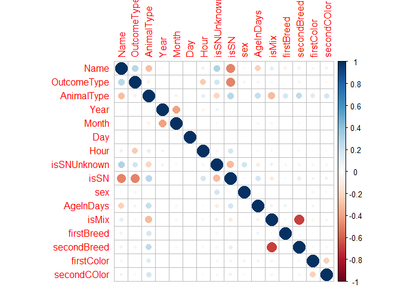

```r
train_outcome_num = train
train_outcome_num$OutcomeType = as.numeric(train_outcome_num$OutcomeType)
corrplot(cor(train_outcome_num))
```

En segundo lugar, se mostrará un diagrama de cajas y bigotes con el objetivo de poder visualizar algún outlier quizás.

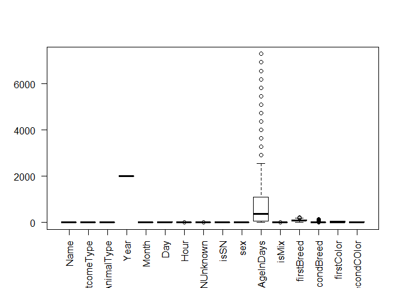

```r
boxplot(train_outcome_num, las = 2)
```

A través de este análisis estadístico, se observa que existen una gran cantidad de outliers sobre todo en la edad, para solucionar este hecho realizaremos una limpieza de estos valores. Los valores atípicos en los valores booleanos se ignorarán al igual que las demás clases debido a la descompensación entre los distintos valores.

```r
train$AgeInDays = remove_outliers(train$AgeInDays)
train = train[!is.na(train$AgeInDays),]
write.csv(train, "train_processed.csv", row.names = FALSE)
```

Por último se mostrará la distribución de las distintas variables mediante un histograma.

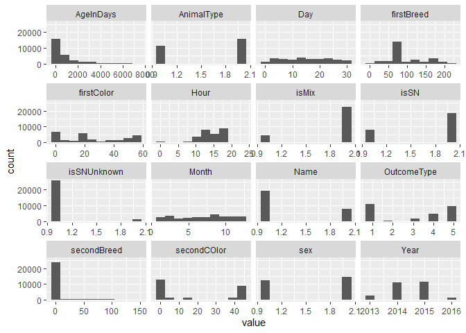

De esta gráfica se obtiene información muy útil como saber cual es la proporción total de animales con mezcla, saber que el primer y último año tiene menos valores. Además, las horas se concentran mayoritariamente en horas más centrales con tendencia a la tarde.

A partir de este momento, los datos ya se encuentran listos para poder pasar a la fase de modelado.

### Modelado

Durante esta fase se realizarán experimentos con distintos modelos con el objetivo de seleccionar aquel que mejores resultados aporte. El proceso será el siguiente, en primer lugar durante el entrenamiento, se preprocesarán los datos de distintas formas y se realizará la validación mediante repeated cross validation y .625Bootstrap en caso de que se vea necesario. Dado que en la competición se usa el logLoss como medida de evaluación, se usará solo esta métrica para poder comparar o evaluar a los modelos.

El conjunto de entrenamiento no será particionado ya que los métodos usados para entrenar solo incluirán una validación cruzada o muestra bootstrap. Por lo tanto, los valores obtenidos serán suficientes como para poder estudiar la capacidad de generalización de los modelos. Para obtener una comparación justa, en todos los modelos se realizará una búsqueda de 10 combinaciones de parámetros escogidos de forma aleatoria con 10 divisiones de la validación cruzada con 3 repeticiones.

Los modelos escogidos son los siguientes:

- LDA: El modelo discriminante lineal trata de obtener aquellos hiperplanos que separa el espacio en tantos grupos como clase.
- XGBTree: Gradient boosting Machine y XGBTree son algoritmos que hacen uso del gradient boosting en el que se entrenan varios clasificadores “débiles” (clasificadores no muy complejos) de forma secuencial de manera que el siguiente modelo logre clasificar correctamente los ejemplos que el anterior modelo no fue capaz.

En primer lugar, se probará con un modelo lineal discriminante.

```r
train_control<- trainControl(method="repeatedcv", number=10,repeats=3, classProbs= TRUE, summaryFunction = multiClassSummary, search = "random")
ldaModel <- train(  x = train[, names(train) != "OutcomeType"],
    y = train$OutcomeType, data=train,method="lda", trControl=train_control,preProc=c("range","YeoJohnson"), metric="logLoss", tuneLength=10)
ldaModel
```

```
## Linear Discriminant Analysis
##
## 24687 samples
##    15 predictor
##     5 classes: 'Adoption', 'Died', 'Euthanasia', 'Return_to_owner', 'Transfer'
##
## Pre-processing: re-scaling to [0, 1] (15), Yeo-Johnson transformation (8)
## Resampling: Cross-Validated (10 fold, repeated 3 times)
## Summary of sample sizes: 22218, 22219, 22218, 22219, 22219, 22218, ...
## Resampling results:
##
##   logLoss    AUC        prAUC     Accuracy   Kappa      Mean_F1
##   0.8605272  0.8342687  0.452242  0.6553114  0.4519437  NaN
##   Mean_Sensitivity  Mean_Specificity  Mean_Pos_Pred_Value  Mean_Neg_Pred_Value
##   0.377205          0.8904674         NaN                  0.9032375
##   Mean_Precision  Mean_Recall  Mean_Detection_Rate  Mean_Balanced_Accuracy
##   NaN             0.377205     0.1310623            0.6338362
```

```r
saveRDS(ldaModel, "models/lda_range_yeojohnson.rds")
```

[output not shown]

Posteriormente se probará realizar una normalización, una trasformación de potencia llamada Yeo-Johnson y posteriormente un análisis de componentes principales en el que se elegirán las componentes que expliquen en 80% de la varibilidad del modelo.

Nota: Cuando se realiza un PCA se realiza un escalado también.

```
##       OutcomeType        PC1        PC2        PC3        PC4        PC5
## 1 Return_to_owner -1.1639925  0.5295542 -0.8682663  1.6586335  0.5719423
## 2      Euthanasia  0.4700302  1.4688292  1.7776860 -0.9533481 -0.2727797
## 3        Adoption -0.9545870  0.1951959 -2.0301459  1.7841811  0.9980472
## 4        Transfer  2.2640275 -0.4393108  0.7538075  0.1531557 -0.6147830
## 5        Transfer -1.9594784 -3.0447013  2.8386484 -1.4426969  1.5114441
## 6        Transfer -1.0532817 -2.3892477  0.9387126  0.8671560 -1.3133483
##           PC6        PC7        PC8        PC9        PC10
## 1 -0.79429100 -0.8721391  1.6510899  0.3380152  0.51129671
## 2  0.64345989 -0.2277794 -0.7190981  0.5719642 -0.54667436
## 3  0.28726872  1.6734122  0.7761411  0.5864799  0.49130508
## 4 -1.04117740 -0.7937684  0.6605326  0.2794924 -0.52185676
## 5 -0.06383263 -0.3219859 -0.3038167  0.4501536  0.11879108
## 6  1.61430151  1.2555741  0.2536886 -0.5374572 -0.03689033
```

```
## Linear Discriminant Analysis
##
## 24687 samples
##    10 predictor
##     5 classes: 'Adoption', 'Died', 'Euthanasia', 'Return_to_owner', 'Transfer'
##
## Pre-processing: re-scaling to [0, 1] (10), Yeo-Johnson transformation (10)
## Resampling: Cross-Validated (10 fold, repeated 3 times)
## Summary of sample sizes: 22216, 22219, 22218, 22218, 22219, 22219, ...
## Resampling results:
##
##   logLoss    AUC        prAUC      Accuracy   Kappa      Mean_F1
##   0.9166694  0.8095562  0.4155425  0.6412289  0.4314192  NaN
##   Mean_Sensitivity  Mean_Specificity  Mean_Pos_Pred_Value  Mean_Neg_Pred_Value
##   0.3618753         0.8868046         NaN                  0.8959222
##   Mean_Precision  Mean_Recall  Mean_Detection_Rate  Mean_Balanced_Accuracy
##   NaN             0.3618753    0.1282458            0.6243399
```

Por último se evaluará si los resultados son muy distintos para otro método de estimación del error, en este caso se usará el método .632Bootstrap. La técnica 0.632 bootstrap que tal y como indica su nombre toma muestras bootstrap para realizar el entrenamiento del modelo. Sin embargo, a la hora de realizar el cálculo del error se tienen en cuenta los errores cometidos por los ejemplos dentro de la muestra y los ejemplos fuera de la muestra. La proporción de ejemplos dentro de la muestra son 63.2% ~ 2/3, de ahí su nombre.

```
## Linear Discriminant Analysis
##
## 24687 samples
##    10 predictor
##     5 classes: 'Adoption', 'Died', 'Euthanasia', 'Return_to_owner', 'Transfer'
##
## Pre-processing: re-scaling to [0, 1] (10), Yeo-Johnson transformation (10)
## Resampling: Bootstrapped (10 reps)
## Summary of sample sizes: 24687, 24687, 24687, 24687, 24687, 24687, ...
## Resampling results:
##
##   logLoss    AUC        prAUC     Accuracy   Kappa      Mean_F1
##   0.9154729  0.8123153  0.415734  0.6412717  0.4310339  NaN
##   Mean_Sensitivity  Mean_Specificity  Mean_Pos_Pred_Value  Mean_Neg_Pred_Value
##   0.361376          0.8867157         NaN                  0.8959464
##   Mean_Precision  Mean_Recall  Mean_Detection_Rate  Mean_Balanced_Accuracy
##   NaN             0.361376     0.1282543            0.6240458
```

El uso de otro método de validación no ofrece una diferencia muy significativa respecto al la validación cruzada. Por lo tanto, en principio se podría afirmar que no importa el uso de uno u otro.

Tal y como se observa, el preprocesado con las funciones de range y YeoJohnsonproducen mejores resultados en este caso teniendo en cuenta que en el problema que se está tratando lo que se intenta minimizar lo máximo es el LogLoss. Si se observaran otras medidas de clasificación como por ejemplo el AUC, la selección podría no ser esta.

```r
results = resamples(list(ldaPCA=ldaModelpca, LDA_CS = ldaModel_cs, LDA_RY = ldaModel))

summary(results)
```

```
##
## Call:
## summary.resamples(object = results)
##
## Models: ldaPCA, LDA_CS, LDA_RY
## Number of resamples: 30
##
## Accuracy
##             Min.   1st Qu.    Median      Mean   3rd Qu.      Max. NA's
## ldaPCA 0.6244435 0.6356181 0.6407452 0.6412289 0.6457068 0.6592382    0
## LDA_CS 0.6349656 0.6492507 0.6532308 0.6545966 0.6594775 0.6843598    0
## LDA_RY 0.6341167 0.6499544 0.6553890 0.6553114 0.6612673 0.6735520    0
##
## AUC
##             Min.   1st Qu.    Median      Mean   3rd Qu.      Max. NA's
## ldaPCA 0.7916713 0.8024864 0.8076582 0.8095562 0.8167296 0.8323305    0
## LDA_CS 0.8041846 0.8207481 0.8273920 0.8268034 0.8336226 0.8446756    0
## LDA_RY 0.8133314 0.8275371 0.8344574 0.8342687 0.8394452 0.8530887    0
##
## Kappa
##             Min.   1st Qu.    Median      Mean   3rd Qu.      Max. NA's
## ldaPCA 0.4041734 0.4234030 0.4308463 0.4314192 0.4379780 0.4604403    0
## LDA_CS 0.4223582 0.4435560 0.4486465 0.4515164 0.4583840 0.4987020    0
## LDA_RY 0.4178947 0.4431417 0.4527111 0.4519437 0.4604357 0.4809371    0
##
## logLoss
##             Min.   1st Qu.    Median      Mean   3rd Qu.      Max. NA's
## ldaPCA 0.8783911 0.9085099 0.9147757 0.9166694 0.9240562 0.9423921    0
## LDA_CS 0.8581692 0.8726985 0.8839752 0.8852169 0.8960286 0.9251116    0
## LDA_RY 0.8218670 0.8507699 0.8625976 0.8605272 0.8691087 0.9003503    0
##
## Mean_Balanced_Accuracy
##             Min.   1st Qu.    Median      Mean   3rd Qu.      Max. NA's
## ldaPCA 0.6162079 0.6217872 0.6242360 0.6243399 0.6263464 0.6329054    0
## LDA_CS 0.6237741 0.6289431 0.6320356 0.6321803 0.6339603 0.6475726    0
## LDA_RY 0.6225473 0.6311764 0.6339650 0.6338362 0.6371612 0.6435479    0
##
## Mean_Detection_Rate
##             Min.   1st Qu.    Median      Mean   3rd Qu.      Max. NA's
## ldaPCA 0.1248887 0.1271236 0.1281490 0.1282458 0.1291414 0.1318476    0
```

[output cut: 35 more lines]

```
## ldaPCA 0.3511882 0.3582102 0.3626624 0.3618753 0.3648769 0.3731073    0
## LDA_CS 0.3602599 0.3685696 0.3735034 0.3736750 0.3769679 0.3953253    0
## LDA_RY 0.3613436 0.3728824 0.3776612 0.3772050 0.3816461 0.3908034    0
##
## Mean_Specificity
##             Min.   1st Qu.    Median      Mean   3rd Qu.      Max. NA's
## ldaPCA 0.8812276 0.8854525 0.8867418 0.8868046 0.8880083 0.8927035    0
## LDA_CS 0.8851046 0.8889997 0.8900430 0.8906856 0.8921009 0.8998199    0
## LDA_RY 0.8837511 0.8884009 0.8908350 0.8904674 0.8921116 0.8962924    0
##
## prAUC
##             Min.   1st Qu.    Median      Mean   3rd Qu.      Max. NA's
## ldaPCA 0.4020813 0.4116817 0.4146376 0.4155425 0.4214475 0.4271826    0
## LDA_CS 0.4226277 0.4302269 0.4357750 0.4365151 0.4432320 0.4544336    0
## LDA_RY 0.4378270 0.4460551 0.4525470 0.4522420 0.4567897 0.4714036    0
```

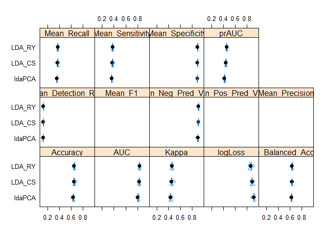

```r
bwplot(results)
```

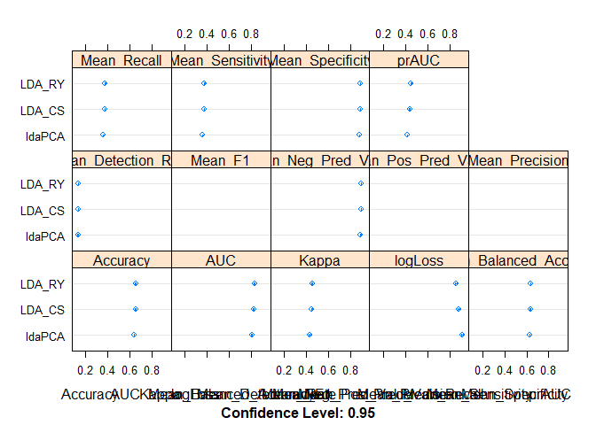

```r
dotplot(results)
```

Por lo tanto, se usará este preprocesado en los modelos que consuman mayor tiempo de cómputo con la apuesta de que el preprocesado sea el mejor para estos también. Esta regla no tiene porqué aplicarse con ellos, ya que los modelos son muy variados y puede que las transformaciones aplicadas no sean las más adecuadas. Sin embargo, con el objetivo de ahorrar el mayor tiempo posible intentando lograr los mejores resultados, se ha realizado las pruebas con un modelo simple y rápido de entrenar. Esta es una apuesta que en la realidad debería tener en cuenta el factor del tiempo disponible, dado que no se establece un valor de error límite se dará prioridad al tiempo.

Se estudiará el comportamiento con otros modelos más complejos con el fin de mejorar los resultados obtenidos.

A continuación, se realizarán pruebas con un random forest en el que el número de árboles se ha establecido a 500

```
## Random Forest
##
## 24687 samples
##    15 predictor
##     5 classes: 'Adoption', 'Died', 'Euthanasia', 'Return_to_owner', 'Transfer'
##
## Pre-processing: re-scaling to [0, 1] (15), Yeo-Johnson transformation (8)
## Resampling: Cross-Validated (10 fold, repeated 3 times)
## Summary of sample sizes: 22219, 22220, 22218, 22218, 22217, 22219, ...
## Resampling results:
##
##   logLoss    AUC        prAUC      Accuracy   Kappa      Mean_F1
##   0.7850768  0.8682958  0.5394799  0.6935358  0.5197701  0.4709886
##   Mean_Sensitivity  Mean_Specificity  Mean_Pos_Pred_Value  Mean_Neg_Pred_Value
##   0.4366303         0.9046304         0.6609306            0.9126048
##   Mean_Precision  Mean_Recall  Mean_Detection_Rate  Mean_Balanced_Accuracy
##   0.6609306       0.4366303    0.1387072            0.6706303
##
## Tuning parameter 'mtry' was held constant at a value of 4
```

```
## eXtreme Gradient Boosting
##
## 24687 samples
##    15 predictor
##     5 classes: 'Adoption', 'Died', 'Euthanasia', 'Return_to_owner', 'Transfer'
##
## Pre-processing: re-scaling to [0, 1] (15), Yeo-Johnson transformation (15)
## Resampling: Cross-Validated (10 fold, repeated 3 times)
## Summary of sample sizes: 22219, 22219, 22217, 22218, 22218, 22219, ...
## Resampling results across tuning parameters:
##
##   eta        max_depth  gamma     colsample_bytree  min_child_weight  subsample
##   0.1260548  8          4.088769  0.3807071          3                0.3096753
##   0.1930577  2          6.382319  0.5176750         13                0.9597874
##   0.2208995  6          8.350069  0.4183185         10                0.7884656
##   0.3473739  6          2.357227  0.3350501         15                0.7585398
##   0.3698795  4          1.861790  0.5234517          7                0.8199574
##   0.3734555  4          2.169385  0.3060120         15                0.8672595
##   0.4461846  4          9.068111  0.6814009         10                0.4624331
##   0.4835452  9          9.066773  0.5065395          5                0.4669848
##   0.5509407  9          3.754631  0.3190226         11                0.5411115
##   0.5710416  3          2.875824  0.4920096          0                0.5263950
##   nrounds  logLoss    AUC        prAUC      Accuracy   Kappa      Mean_F1
##   786      0.7484428  0.8725397  0.5287508  0.6891745  0.5140509  0.4674153
##   794      0.7789072  0.8626361  0.5045804  0.6755102  0.4865600  0.4145935
##   889      0.7558460  0.8711830  0.5259073  0.6872166  0.5089080  0.4509576
##   595      0.7442024  0.8744049  0.5326027  0.6895802  0.5174976  0.4828691
##   521      0.7451419  0.8726910  0.5349656  0.6895799  0.5175417  0.4884426
##    17      0.8234794  0.8526922  0.4911068  0.6674228  0.4665267        NaN
##   465      0.7676224  0.8660063  0.5150489  0.6827472  0.5015053  0.4417919
##    43      0.7764043  0.8641362  0.5091912  0.6795745  0.4954174  0.4324003
##   389      0.7548229  0.8700755  0.5227128  0.6854885  0.5101604  0.4734654
##   954      0.7610990  0.8664598  0.5211345  0.6835846  0.5081978  0.4786381
##   Mean_Sensitivity  Mean_Specificity  Mean_Pos_Pred_Value  Mean_Neg_Pred_Value
##   0.4328094         0.9034671         0.6370557            0.9108698
##   0.3941129         0.8976549         0.5972053            0.9082398
##   0.4180263         0.9023101         0.6503252            0.9107919
##   0.4500268         0.9044535         0.6293665            0.9104861
##   0.4557990         0.9044326         0.6267726            0.9105063
##   0.3723936         0.8930825               NaN            0.9086110
##   0.4129691         0.9008382         0.6128543            0.9095474
##   0.4036146         0.8995955         0.6180297            0.9087233
##   0.4396523         0.9029141         0.6112991            0.9092676
##   0.4477355         0.9026098         0.5879913            0.9086024
##   Mean_Precision  Mean_Recall  Mean_Detection_Rate  Mean_Balanced_Accuracy
##   0.6370557       0.4328094    0.1378349            0.6681382
##   0.5972053       0.3941129    0.1351020            0.6458839
##   0.6503252       0.4180263    0.1374433            0.6601682
##   0.6293665       0.4500268    0.1379160            0.6772402
##   0.6267726       0.4557990    0.1379160            0.6801158
##         NaN       0.3723936    0.1334846            0.6327380
##   0.6128543       0.4129691    0.1365494            0.6569037
##   0.6180297       0.4036146    0.1359149            0.6516051
##   0.6112991       0.4396523    0.1370977            0.6712832
##   0.5879913       0.4477355    0.1367169            0.6751727
##
## logLoss was used to select the optimal model using the smallest value.
## The final values used for the model were nrounds = 595, max_depth = 6, eta
##  = 0.3473739, gamma = 2.357227, colsample_bytree = 0.3350501,
##  min_child_weight = 15 and subsample = 0.7585398.
```

A continuación, para finalizar con la fase de modelado se compararán los modelos más complejos con los más sencillos vistos anteriormente.

```r
xgbTree = readRDS('models/xgbTree_no_selection.rds')
xgbTree
```

```
## eXtreme Gradient Boosting
##
## 24687 samples
##    15 predictor
##     5 classes: 'Adoption', 'Died', 'Euthanasia', 'Return_to_owner', 'Transfer'
##
## Pre-processing: re-scaling to [0, 1] (15), Yeo-Johnson transformation (15)
## Resampling: Cross-Validated (10 fold, repeated 3 times)
## Summary of sample sizes: 22219, 22219, 22217, 22218, 22218, 22219, ...
## Resampling results across tuning parameters:
##
##   eta        max_depth  gamma     colsample_bytree  min_child_weight  subsample
##   0.1260548  8          4.088769  0.3807071          3                0.3096753
##   0.1930577  2          6.382319  0.5176750         13                0.9597874
##   0.2208995  6          8.350069  0.4183185         10                0.7884656
##   0.3473739  6          2.357227  0.3350501         15                0.7585398
##   0.3698795  4          1.861790  0.5234517          7                0.8199574
##   0.3734555  4          2.169385  0.3060120         15                0.8672595
##   0.4461846  4          9.068111  0.6814009         10                0.4624331
##   0.4835452  9          9.066773  0.5065395          5                0.4669848
##   0.5509407  9          3.754631  0.3190226         11                0.5411115
##   0.5710416  3          2.875824  0.4920096          0                0.5263950
##   nrounds  logLoss    AUC        prAUC      Accuracy   Kappa      Mean_F1
##   786      0.7484428  0.8725397  0.5287508  0.6891745  0.5140509  0.4674153
##   794      0.7789072  0.8626361  0.5045804  0.6755102  0.4865600  0.4145935
##   889      0.7558460  0.8711830  0.5259073  0.6872166  0.5089080  0.4509576
##   595      0.7442024  0.8744049  0.5326027  0.6895802  0.5174976  0.4828691
##   521      0.7451419  0.8726910  0.5349656  0.6895799  0.5175417  0.4884426
##    17      0.8234794  0.8526922  0.4911068  0.6674228  0.4665267        NaN
##   465      0.7676224  0.8660063  0.5150489  0.6827472  0.5015053  0.4417919
##    43      0.7764043  0.8641362  0.5091912  0.6795745  0.4954174  0.4324003
##   389      0.7548229  0.8700755  0.5227128  0.6854885  0.5101604  0.4734654
##   954      0.7610990  0.8664598  0.5211345  0.6835846  0.5081978  0.4786381
##   Mean_Sensitivity  Mean_Specificity  Mean_Pos_Pred_Value  Mean_Neg_Pred_Value
##   0.4328094         0.9034671         0.6370557            0.9108698
##   0.3941129         0.8976549         0.5972053            0.9082398
##   0.4180263         0.9023101         0.6503252            0.9107919
##   0.4500268         0.9044535         0.6293665            0.9104861
##   0.4557990         0.9044326         0.6267726            0.9105063
##   0.3723936         0.8930825               NaN            0.9086110
##   0.4129691         0.9008382         0.6128543            0.9095474
##   0.4036146         0.8995955         0.6180297            0.9087233
##   0.4396523         0.9029141         0.6112991            0.9092676
##   0.4477355         0.9026098         0.5879913            0.9086024
##   Mean_Precision  Mean_Recall  Mean_Detection_Rate  Mean_Balanced_Accuracy
##   0.6370557       0.4328094    0.1378349            0.6681382
##   0.5972053       0.3941129    0.1351020            0.6458839
##   0.6503252       0.4180263    0.1374433            0.6601682
##   0.6293665       0.4500268    0.1379160            0.6772402
##   0.6267726       0.4557990    0.1379160            0.6801158
##         NaN       0.3723936    0.1334846            0.6327380
##   0.6128543       0.4129691    0.1365494            0.6569037
##   0.6180297       0.4036146    0.1359149            0.6516051
##   0.6112991       0.4396523    0.1370977            0.6712832
##   0.5879913       0.4477355    0.1367169            0.6751727
##
## logLoss was used to select the optimal model using the smallest value.
## The final values used for the model were nrounds = 595, max_depth = 6, eta
##  = 0.3473739, gamma = 2.357227, colsample_bytree = 0.3350501,
##  min_child_weight = 15 and subsample = 0.7585398.
```

```r
rf = readRDS('models/rf.rds')
gbm = readRDS('models/gbm.rds')
ldaModel = readRDS('models/lda_range_yeojohnson.rds')
ldaModelpca = readRDS('models/lda_range_yeojohnson_pca.rds')
ldaModel_cs = readRDS('models/lda_center_scale.rds')

results = resamples(list(XGBTree=xgbTree, RF=rf, LDA_RY=ldaModel, LDA_CS = ldaModel_cs, LDA_RYPCA = ldaModelpca ))

summary(results)
```

```
##
## Call:
## summary.resamples(object = results)
##
## Models: XGBTree, RF, LDA_RY, LDA_CS, LDA_RYPCA
## Number of resamples: 30
##
## Accuracy
##                Min.   1st Qu.    Median      Mean   3rd Qu.      Max. NA's
## XGBTree   0.6788173 0.6820621 0.6888790 0.6895802 0.6952911 0.7075739    0
## RF        0.6715269 0.6888798 0.6942700 0.6935358 0.6974484 0.7058347    0
## LDA_RY    0.6341167 0.6499544 0.6553890 0.6553114 0.6612673 0.6735520    0
## LDA_CS    0.6349656 0.6492507 0.6532308 0.6545966 0.6594775 0.6843598    0
## LDA_RYPCA 0.6244435 0.6356181 0.6407452 0.6412289 0.6457068 0.6592382    0
##
## AUC
##                Min.   1st Qu.    Median      Mean   3rd Qu.      Max. NA's
## XGBTree   0.8591637 0.8703891 0.8746082 0.8744049 0.8782582 0.8917795    0
## RF        0.8467353 0.8632616 0.8682613 0.8682958 0.8743710 0.8875751    0
## LDA_RY    0.8133314 0.8275371 0.8344574 0.8342687 0.8394452 0.8530887    0
## LDA_CS    0.8041846 0.8207481 0.8273920 0.8268034 0.8336226 0.8446756    0
## LDA_RYPCA 0.7916713 0.8024864 0.8076582 0.8095562 0.8167296 0.8323305    0
##
## Kappa
##                Min.   1st Qu.    Median      Mean   3rd Qu.      Max. NA's
## XGBTree   0.5019720 0.5066137 0.5153994 0.5174976 0.5248835 0.5439824    0
## RF        0.4848026 0.5134691 0.5209197 0.5197701 0.5271432 0.5393219    0
## LDA_RY    0.4178947 0.4431417 0.4527111 0.4519437 0.4604357 0.4809371    0
## LDA_CS    0.4223582 0.4435560 0.4486465 0.4515164 0.4583840 0.4987020    0
## LDA_RYPCA 0.4041734 0.4234030 0.4308463 0.4314192 0.4379780 0.4604403    0
##
## logLoss
##                Min.   1st Qu.    Median      Mean   3rd Qu.      Max. NA's
## XGBTree   0.7206857 0.7325148 0.7430579 0.7442024 0.7554599 0.7760353    0
## RF        0.7286227 0.7681773 0.7833620 0.7850768 0.8038618 0.8372647    0
## LDA_RY    0.8218670 0.8507699 0.8625976 0.8605272 0.8691087 0.9003503    0
## LDA_CS    0.8581692 0.8726985 0.8839752 0.8852169 0.8960286 0.9251116    0
## LDA_RYPCA 0.8783911 0.9085099 0.9147757 0.9166694 0.9240562 0.9423921    0
##
## Mean_Balanced_Accuracy
```

[output cut: 63 more lines]

```
## Mean_Specificity
##                Min.   1st Qu.    Median      Mean   3rd Qu.      Max. NA's
## XGBTree   0.9012901 0.9024139 0.9039882 0.9044535 0.9061925 0.9096637    0
## RF        0.8976701 0.9035939 0.9049828 0.9046304 0.9061756 0.9083184    0
## LDA_RY    0.8837511 0.8884009 0.8908350 0.8904674 0.8921116 0.8962924    0
## LDA_CS    0.8851046 0.8889997 0.8900430 0.8906856 0.8921009 0.8998199    0
## LDA_RYPCA 0.8812276 0.8854525 0.8867418 0.8868046 0.8880083 0.8927035    0
##
## prAUC
##                Min.   1st Qu.    Median      Mean   3rd Qu.      Max. NA's
## XGBTree   0.4959682 0.5214667 0.5338012 0.5326027 0.5429370 0.5789813    0
## RF        0.5004041 0.5220783 0.5453549 0.5394799 0.5526572 0.5803949    0
## LDA_RY    0.4378270 0.4460551 0.4525470 0.4522420 0.4567897 0.4714036    0
## LDA_CS    0.4226277 0.4302269 0.4357750 0.4365151 0.4432320 0.4544336    0
## LDA_RYPCA 0.4020813 0.4116817 0.4146376 0.4155425 0.4214475 0.4271826    0
```

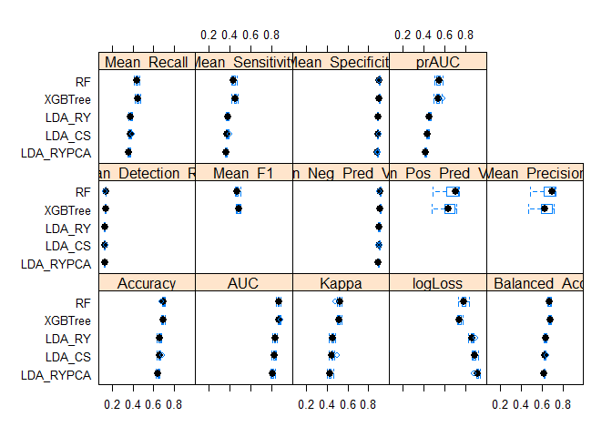

```r
bwplot(results)
```

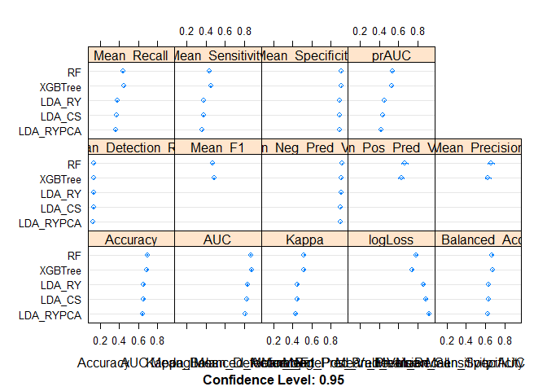

```r
dotplot(results)
```

### Selección de atributos

Dado un modelo, se puede analizar la importancia de cada variable a la hora de realizar la predicción. Se analizarán las variables implicadas en el modelo lineal ya que en el caso de un essemble los atributos escogidos no están claros.

```r
varImp(ldaModel)
```

```
## ROC curve variable importance
##
##   variables are sorted by maximum importance across the classes
##             Adoption    Died Euthanasia Return_to_owner Transfer
## isSN         100.000 100.000   100.0000         100.000   78.291
## AgeInDays     59.160  65.015    59.1599          67.132   65.015
## Hour          66.440  66.440    66.4404          66.440   41.610
## Name          55.459  55.459    55.4586          55.459   44.281
## AnimalType    44.147  44.147    44.1467          44.147   33.633
## firstBreed    14.068  10.539     0.2752          19.159   14.068
## Year           8.331   5.624     5.6244          17.017    8.331
## isSNUnknown   14.561  14.561    14.5606          14.561    6.832
## sex           14.088  14.088    14.0884          14.088   11.467
## firstColor    12.164  12.164    12.1637          12.164    1.319
## isMix         10.927  10.927    10.9268          10.927    5.871
## secondBreed   10.273  10.273    10.2729          10.273    5.238
## secondCOlor    3.849   3.854     7.4372           4.934    3.854
## Month          1.474   4.165     1.4738           1.474    4.165
## Day            3.979   3.979     3.9786           3.979    0.000
```

En la siguiente tabla se muestra un ranking de variables y la importancia por cada clase. Como se observa la variable más importante es saber si están castrados/esterilizados, mientras que los valores con menos importancia son el segundo color, el mes y el día. Reducir la dimensionalidad del problema puede ayudar a evitar el sobreajuste de los modelos. Por ello, se eliminará la variable que menos aporta.

```
## Linear Discriminant Analysis
##
## 24687 samples
##    14 predictor
##     5 classes: 'Adoption', 'Died', 'Euthanasia', 'Return_to_owner', 'Transfer'
##
## Pre-processing: re-scaling to [0, 1] (14), Yeo-Johnson transformation (7)
## Resampling: Cross-Validated (10 fold, repeated 3 times)
## Summary of sample sizes: 22218, 22218, 22219, 22219, 22219, 22217, ...
## Resampling results:
##
##   logLoss    AUC        prAUC      Accuracy   Kappa     Mean_F1
##   0.8604816  0.8344693  0.4524417  0.6546496  0.450679  NaN
##   Mean_Sensitivity  Mean_Specificity  Mean_Pos_Pred_Value  Mean_Neg_Pred_Value
##   0.3761146         0.8902111         NaN                  0.9030662
##   Mean_Precision  Mean_Recall  Mean_Detection_Rate  Mean_Balanced_Accuracy
##   NaN             0.3761146    0.1309299            0.6331628
```

A continuación, se realizará la eliminación del la variable Month con el objetivo de visualizar el efecto en el error.

```
## Linear Discriminant Analysis
##
## 24687 samples
##    14 predictor
##     5 classes: 'Adoption', 'Died', 'Euthanasia', 'Return_to_owner', 'Transfer'
##
## Pre-processing: re-scaling to [0, 1] (14), Yeo-Johnson transformation (7)
## Resampling: Cross-Validated (10 fold, repeated 3 times)
## Summary of sample sizes: 22219, 22218, 22217, 22219, 22219, 22217, ...
## Resampling results:
##
##   logLoss    AUC        prAUC      Accuracy   Kappa      Mean_F1
##   0.8602207  0.8347059  0.4536777  0.6553521  0.4518498  NaN
##   Mean_Sensitivity  Mean_Specificity  Mean_Pos_Pred_Value  Mean_Neg_Pred_Value
##   0.3768049         0.8904386         NaN                  0.9032946
##   Mean_Precision  Mean_Recall  Mean_Detection_Rate  Mean_Balanced_Accuracy
##   NaN             0.3768049    0.1310704            0.6336217
```

```r
# detach(train)
# attach(train_selection)
# train_control <- trainControl(classProbs= TRUE, summaryFunction = multiClassSummary, verboseIter = TRUE, search = "random")
# xgbTree <- train( OutcomeType ~ ., data=train_selection,
#                              method = "xgbTree",
#                              trControl = train_control,
#                              metric = "logLoss",
#                              preProc = c("range", "YeoJohnson"), verbose=TRUE, tuneLength=10)
xgbTree
```

```
## eXtreme Gradient Boosting
##
## 24687 samples
##    15 predictor
##     5 classes: 'Adoption', 'Died', 'Euthanasia', 'Return_to_owner', 'Transfer'
##
## Pre-processing: re-scaling to [0, 1] (15), Yeo-Johnson transformation (15)
## Resampling: Cross-Validated (10 fold, repeated 3 times)
## Summary of sample sizes: 22219, 22219, 22217, 22218, 22218, 22219, ...
## Resampling results across tuning parameters:
##
##   eta        max_depth  gamma     colsample_bytree  min_child_weight  subsample
##   0.1260548  8          4.088769  0.3807071          3                0.3096753
##   0.1930577  2          6.382319  0.5176750         13                0.9597874
##   0.2208995  6          8.350069  0.4183185         10                0.7884656
##   0.3473739  6          2.357227  0.3350501         15                0.7585398
##   0.3698795  4          1.861790  0.5234517          7                0.8199574
##   0.3734555  4          2.169385  0.3060120         15                0.8672595
##   0.4461846  4          9.068111  0.6814009         10                0.4624331
##   0.4835452  9          9.066773  0.5065395          5                0.4669848
##   0.5509407  9          3.754631  0.3190226         11                0.5411115
##   0.5710416  3          2.875824  0.4920096          0                0.5263950
##   nrounds  logLoss    AUC        prAUC      Accuracy   Kappa      Mean_F1
##   786      0.7484428  0.8725397  0.5287508  0.6891745  0.5140509  0.4674153
##   794      0.7789072  0.8626361  0.5045804  0.6755102  0.4865600  0.4145935
##   889      0.7558460  0.8711830  0.5259073  0.6872166  0.5089080  0.4509576
##   595      0.7442024  0.8744049  0.5326027  0.6895802  0.5174976  0.4828691
##   521      0.7451419  0.8726910  0.5349656  0.6895799  0.5175417  0.4884426
##    17      0.8234794  0.8526922  0.4911068  0.6674228  0.4665267        NaN
##   465      0.7676224  0.8660063  0.5150489  0.6827472  0.5015053  0.4417919
##    43      0.7764043  0.8641362  0.5091912  0.6795745  0.4954174  0.4324003
##   389      0.7548229  0.8700755  0.5227128  0.6854885  0.5101604  0.4734654
##   954      0.7610990  0.8664598  0.5211345  0.6835846  0.5081978  0.4786381
##   Mean_Sensitivity  Mean_Specificity  Mean_Pos_Pred_Value  Mean_Neg_Pred_Value
##   0.4328094         0.9034671         0.6370557            0.9108698
##   0.3941129         0.8976549         0.5972053            0.9082398
##   0.4180263         0.9023101         0.6503252            0.9107919
##   0.4500268         0.9044535         0.6293665            0.9104861
##   0.4557990         0.9044326         0.6267726            0.9105063
##   0.3723936         0.8930825               NaN            0.9086110
##   0.4129691         0.9008382         0.6128543            0.9095474
##   0.4036146         0.8995955         0.6180297            0.9087233
##   0.4396523         0.9029141         0.6112991            0.9092676
##   0.4477355         0.9026098         0.5879913            0.9086024
##   Mean_Precision  Mean_Recall  Mean_Detection_Rate  Mean_Balanced_Accuracy
##   0.6370557       0.4328094    0.1378349            0.6681382
##   0.5972053       0.3941129    0.1351020            0.6458839
##   0.6503252       0.4180263    0.1374433            0.6601682
##   0.6293665       0.4500268    0.1379160            0.6772402
##   0.6267726       0.4557990    0.1379160            0.6801158
##         NaN       0.3723936    0.1334846            0.6327380
##   0.6128543       0.4129691    0.1365494            0.6569037
##   0.6180297       0.4036146    0.1359149            0.6516051
##   0.6112991       0.4396523    0.1370977            0.6712832
##   0.5879913       0.4477355    0.1367169            0.6751727
##
## logLoss was used to select the optimal model using the smallest value.
## The final values used for the model were nrounds = 595, max_depth = 6, eta
##  = 0.3473739, gamma = 2.357227, colsample_bytree = 0.3350501,
##  min_child_weight = 15 and subsample = 0.7585398.
```

```r
saveRDS(xgbTree,"models/xgbTree_selected.rds")
xgbTree = readRDS("models/xgbTree_selected.rds")
```

### Resultados

Antes de obtener los resultados, es necesario aplicar el mismo preprocesado realizado al conjunto de entrenamiento al conjunto de test. Sin embargo, hay algunos pequeños cambios respecto al preprocesado realizado al conjunto de entrenamiento. Dado que se precisa que el resultado sea de igual tamaño al conjunto de prueba, no se podrá realizar ninguna acción que elimine los datos tal y como se ha realizado con los outliers y los valores perdidos en la edad y sexo. Por lo tando, será necesario sustituir los valores perdidos, una posible solución sería sustituirlos por la media, pero se intentará obtener una solución mejor usando un randomForest para atribuir esos datos perdidos.

```r
test = read.csv('test.csv', na.strings = "")

test$Name = is.na(test$Name)
test$Year = as.numeric(format(as.Date(test$DateTime), '%Y'))
test$Month = as.numeric(format(as.Date(test$DateTime), '%m'))
test$Day = as.numeric(format(as.Date(test$DateTime), '%d'))
test$Hour = as.numeric(format(as.POSIXct(test$DateTime,format="%Y-%m-%d %H:%M:%S"), '%H'))
test$DateTime = NULL


test$isSNUnknown = test$SexuponOutcome=="Unknown"
test$isSN <- str_split_fixed(as.character(test$SexuponOutcome), " ", 2)[,1]
test$sex <- str_split_fixed(as.character(test$SexuponOutcome), " ", 2)[,2]
test$sex[as.character(test$sex)==""] = "Male"
test$sex[is.na(test$sex)] = "Male"
test$isSN = !(test$isSN %like% "Intact" | test$isSN %like% "Unknown")
test$SexuponOutcome = NULL


ageValue = as.numeric(sapply(as.character(test$AgeuponOutcome),
                      function(x) strsplit(x, split = ' ')[[1]][1]))
ageUnit = sapply(as.character(test$AgeuponOutcome),
                      function(x) strsplit(x, split = ' ')[[1]][2])
ageUnit = gsub('s', '', ageUnit)

daysForUnit = ifelse(ageUnit == 'day', 1,
              ifelse(ageUnit == 'week', 7,
              ifelse(ageUnit == 'month', 30,
              ifelse(ageUnit == 'year', 365, NA))))

length(ageValue * daysForUnit)
```

```
## [1] 11456
```

```r
test$AgeInDays = ageValue * daysForUnit
test$AgeuponOutcome = NULL

test$isMix = tolower(as.character(test$Breed)) %like% "mix"
breedWithoutMix = gsub('mix', '',  tolower(as.character(test$Breed)))
breedWithoutMix = gsub("^\\s+|\\s+$", "", breedWithoutMix)
test$firstBreed <- str_split_fixed(as.character(breedWithoutMix), "/", 2)[,1]
test$secondBreed <- str_split_fixed(as.character(breedWithoutMix), "/", 2)[,2]
test$secondBreed[as.character(test$secondBreed)==""] = NA
test$Breed = NULL

colorTrimmed = gsub("^\\s+|\\s+$", "", test$Color)
test$firstColor <- str_split_fixed(as.character(colorTrimmed), "/", 2)[,1]
test$secondCOlor <- str_split_fixed(as.character(colorTrimmed), "/", 2)[,2]
test$Color = NULL


test$AnimalType = as.numeric(test$AnimalType)
test$sex = as.numeric(as.factor(test$sex))
test$firstBreed = as.numeric(as.factor(test$firstBreed))
test$secondBreed = as.numeric(as.factor(test$secondBreed))
test$firstColor = as.numeric(as.factor(test$firstColor))
test$secondCOlor = as.numeric(as.factor(test$secondCOlor))
test$Name = as.numeric(as.factor(test$Name))
test$isSN = as.numeric(as.factor(test$isSN))
test$isSNUnknown = as.numeric(as.factor(test$isSNUnknown))
test$isMix = as.numeric(as.factor(test$isMix))
test$secondBreed[is.na(test$secondBreed)] = 0

#test$AgeInDays[is.na(test$AgeInDays)] <- mean(test$AgeInDays, na.rm = TRUE)

test = missForest(test, verbose = TRUE)$ximp
```

```
##   missForest iteration 1 in progress...done!
##     estimated error(s): 0.1516952
##     difference(s): 8.49377e-07
##     time: 31.34 seconds
##
##   missForest iteration 2 in progress...done!
##     estimated error(s): 0.151538
##     difference(s): 3.827792e-07
##     time: 34.13 seconds
##
##   missForest iteration 3 in progress...done!
##     estimated error(s): 0.1515859
##     difference(s): 2.445851e-07
##     time: 24.23 seconds
##
##   missForest iteration 4 in progress...done!
##     estimated error(s): 0.1519846
##     difference(s): 3.012127e-07
##     time: 22.96 seconds
```

```r
write.csv("test_processed.csv")
```

```
## "","x"
## "1","test_processed.csv"
```

```r
summary(test)
```

```
##        ID             Name         AnimalType         Year
##  Min.   :    1   Min.   :1.000   Min.   :1.000   Min.   :2013
##  1st Qu.: 2865   1st Qu.:1.000   1st Qu.:1.000   1st Qu.:2014
##  Median : 5728   Median :1.000   Median :2.000   Median :2014
##  Mean   : 5728   Mean   :1.282   Mean   :1.581   Mean   :2014
##  3rd Qu.: 8592   3rd Qu.:2.000   3rd Qu.:2.000   3rd Qu.:2015
##  Max.   :11456   Max.   :2.000   Max.   :2.000   Max.   :2016
##      Month             Day             Hour        isSNUnknown
##  Min.   : 1.000   Min.   : 1.00   Min.   : 0.00   Min.   :1.00
##  1st Qu.: 4.000   1st Qu.: 8.00   1st Qu.:12.00   1st Qu.:1.00
##  Median : 7.000   Median :16.00   Median :15.00   Median :1.00
##  Mean   : 6.935   Mean   :15.75   Mean   :14.52   Mean   :1.04
##  3rd Qu.:10.000   3rd Qu.:23.00   3rd Qu.:17.00   3rd Qu.:1.00
##  Max.   :12.000   Max.   :31.00   Max.   :23.00   Max.   :2.00
##       isSN            sex          AgeInDays          isMix
##  Min.   :1.000   Min.   :1.000   Min.   :   0.0   Min.   :1.000
##  1st Qu.:1.000   1st Qu.:1.000   1st Qu.:  60.0   1st Qu.:2.000
##  Median :2.000   Median :2.000   Median : 365.0   Median :2.000
##  Mean   :1.703   Mean   :1.537   Mean   : 775.7   Mean   :1.836
##  3rd Qu.:2.000   3rd Qu.:2.000   3rd Qu.:1095.0   3rd Qu.:2.000
##  Max.   :2.000   Max.   :2.000   Max.   :8030.0   Max.   :2.000
##    firstBreed      secondBreed        firstColor    secondCOlor
##  Min.   :  1.00   Min.   :  0.000   Min.   : 1.0   Min.   : 1.00
##  1st Qu.: 78.00   1st Qu.:  0.000   1st Qu.: 5.0   1st Qu.: 1.00
##  Median : 80.00   Median :  0.000   Median :18.0   Median : 3.00
##  Mean   : 91.65   Mean   :  6.906   Mean   :23.6   Mean   :15.92
##  3rd Qu.:116.00   3rd Qu.:  0.000   3rd Qu.:45.0   3rd Qu.:37.00
##  Max.   :200.00   Max.   :129.000   Max.   :52.0   Max.   :39.00
```

```r
str(train)
```

```
## 'data.frame':    24687 obs. of  16 variables:
##  $ Name       : int  1 1 1 2 2 1 1 2 1 2 ...
##  $ OutcomeType: Factor w/ 5 levels "Adoption","Died",..: 4 3 1 5 5 5 5 5 1 1 ...
##  $ AnimalType : int  2 1 2 1 2 2 1 1 2 2 ...
##  $ Year       : int  2014 2013 2015 2014 2013 2014 2015 2015 2014 2014 ...
##  $ Month      : int  2 10 1 7 11 4 3 4 2 5 ...
##  $ Day        : int  12 13 31 11 15 25 28 30 4 3 ...
##  $ Hour       : int  18 12 12 19 12 13 13 17 17 7 ...
##  $ isSNUnknown: int  1 1 1 1 1 1 1 2 1 1 ...
##  $ isSN       : int  2 2 2 1 2 1 1 1 2 2 ...
##  $ sex        : int  2 1 2 2 2 1 2 2 1 1 ...
##  $ AgeInDays  : int  365 365 730 21 730 30 21 21 150 365 ...
##  $ isMix      : int  2 2 2 2 1 1 2 2 2 1 ...
##  $ firstBreed : int  182 81 160 81 128 53 81 81 11 53 ...
##  $ secondBreed: int  0 0 0 0 87 42 0 0 0 0 ...
##  $ firstColor : int  16 27 8 9 50 3 13 19 41 55 ...
##  $ secondCOlor: int  43 1 43 1 1 40 1 1 43 1 ...
```

Para obtener los resultados se obtendrán las probabilidades por cada clase de tal manera que dado un ejemplo se proporcionará la probabilidad de sus destinos, además, se le incluirá el ID asociado y se exportará a csv.

```r
xgbTree = readRDS('models/xgbTree_no_selection.rds')
xgbTree
```

```
## eXtreme Gradient Boosting
##
## 24687 samples
##    15 predictor
##     5 classes: 'Adoption', 'Died', 'Euthanasia', 'Return_to_owner', 'Transfer'
##
## Pre-processing: re-scaling to [0, 1] (15), Yeo-Johnson transformation (15)
## Resampling: Cross-Validated (10 fold, repeated 3 times)
## Summary of sample sizes: 22219, 22219, 22217, 22218, 22218, 22219, ...
## Resampling results across tuning parameters:
##
##   eta        max_depth  gamma     colsample_bytree  min_child_weight  subsample
##   0.1260548  8          4.088769  0.3807071          3                0.3096753
##   0.1930577  2          6.382319  0.5176750         13                0.9597874
##   0.2208995  6          8.350069  0.4183185         10                0.7884656
##   0.3473739  6          2.357227  0.3350501         15                0.7585398
##   0.3698795  4          1.861790  0.5234517          7                0.8199574
##   0.3734555  4          2.169385  0.3060120         15                0.8672595
##   0.4461846  4          9.068111  0.6814009         10                0.4624331
##   0.4835452  9          9.066773  0.5065395          5                0.4669848
##   0.5509407  9          3.754631  0.3190226         11                0.5411115
##   0.5710416  3          2.875824  0.4920096          0                0.5263950
##   nrounds  logLoss    AUC        prAUC      Accuracy   Kappa      Mean_F1
##   786      0.7484428  0.8725397  0.5287508  0.6891745  0.5140509  0.4674153
##   794      0.7789072  0.8626361  0.5045804  0.6755102  0.4865600  0.4145935
##   889      0.7558460  0.8711830  0.5259073  0.6872166  0.5089080  0.4509576
##   595      0.7442024  0.8744049  0.5326027  0.6895802  0.5174976  0.4828691
##   521      0.7451419  0.8726910  0.5349656  0.6895799  0.5175417  0.4884426
##    17      0.8234794  0.8526922  0.4911068  0.6674228  0.4665267        NaN
##   465      0.7676224  0.8660063  0.5150489  0.6827472  0.5015053  0.4417919
##    43      0.7764043  0.8641362  0.5091912  0.6795745  0.4954174  0.4324003
##   389      0.7548229  0.8700755  0.5227128  0.6854885  0.5101604  0.4734654
##   954      0.7610990  0.8664598  0.5211345  0.6835846  0.5081978  0.4786381
##   Mean_Sensitivity  Mean_Specificity  Mean_Pos_Pred_Value  Mean_Neg_Pred_Value
##   0.4328094         0.9034671         0.6370557            0.9108698
##   0.3941129         0.8976549         0.5972053            0.9082398
##   0.4180263         0.9023101         0.6503252            0.9107919
##   0.4500268         0.9044535         0.6293665            0.9104861
##   0.4557990         0.9044326         0.6267726            0.9105063
##   0.3723936         0.8930825               NaN            0.9086110
##   0.4129691         0.9008382         0.6128543            0.9095474
##   0.4036146         0.8995955         0.6180297            0.9087233
##   0.4396523         0.9029141         0.6112991            0.9092676
##   0.4477355         0.9026098         0.5879913            0.9086024
##   Mean_Precision  Mean_Recall  Mean_Detection_Rate  Mean_Balanced_Accuracy
##   0.6370557       0.4328094    0.1378349            0.6681382
##   0.5972053       0.3941129    0.1351020            0.6458839
##   0.6503252       0.4180263    0.1374433            0.6601682
##   0.6293665       0.4500268    0.1379160            0.6772402
##   0.6267726       0.4557990    0.1379160            0.6801158
##         NaN       0.3723936    0.1334846            0.6327380
##   0.6128543       0.4129691    0.1365494            0.6569037
##   0.6180297       0.4036146    0.1359149            0.6516051
##   0.6112991       0.4396523    0.1370977            0.6712832
##   0.5879913       0.4477355    0.1367169            0.6751727
##
## logLoss was used to select the optimal model using the smallest value.
## The final values used for the model were nrounds = 595, max_depth = 6, eta
##  = 0.3473739, gamma = 2.357227, colsample_bytree = 0.3350501,
##  min_child_weight = 15 and subsample = 0.7585398.
```

```r
result.probs = predict(xgbTree, test, type = "prob")
result.probs['ID'] = test$ID
write.csv(result.probs, 'result_xgbTree_no_selection.csv', row.names = FALSE)
```